# Measuring Social Vulnerability by Using Factor and Cluster Analysis

### 3.1.2 Pembentukan Faktor Umum dan Interpretasi

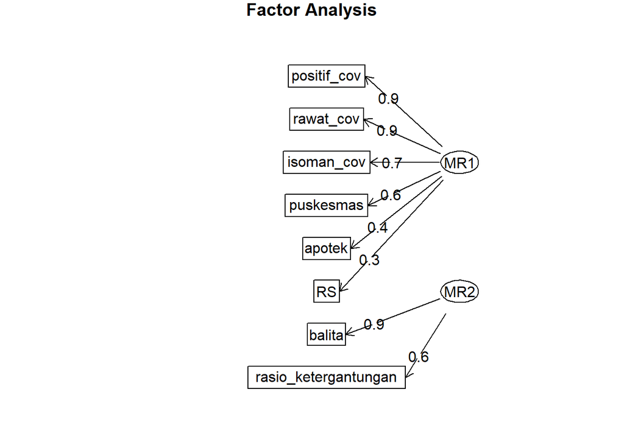

```r
fa.diagram(fa.results = fa_covid_opt,
           rsize = 1)
```

Arah dari masing-masing variabel ditentukan berdasarkan pengaruhnya terhadap kerentanan sosial. Arah positif berpengaruh terhadap peningkatan kerentanan sosial, sebaliknya arah negatif menurunkan tingkat kerentanan sosial.

Dari plot di atas dilakukan pengekstrakan terhadap 2 faktor, yaitu faktor 1 dan faktor 2

### 3.1.3 Indeks Kerentanan Sosial

SoVI merujuk peda Social Vulnerability Index.

### 3.1.4 Melakukan PCA pada data `covid`

*Principal Component Analysis* (PCA)

PCA merupakan suatu algoritma unsupervised learning yang bertujuan untuk *dimentionality reduction*. Salah satu tujuan dari PCA adalah untuk mengubah variabel asli yang saling berkorelasi satu sama lainnya menjadi satu set variabel baru yang memiliki korelasi lebih kecil atau saling bebas.

Ide dasar dari PCA adalah untuk membuat sumbu (axis) baru yang dapat menangkap informasi sebesar mungkin. Sumbu baru ini adalah yang dinamakan sebagai **Principal Component (PC)**. Untuk melakukan dimensionality reduction, kita akan memilih beberapa PC untuk dapat merangkum informasi yang dibutuhkan. Nilai masing-masing PC dibentuk dari matriks varian-kovarians dari suatu set variabel melalui kombinasi linear dari variabel-variabel tersebut.

```r
# membuat object PCA
covid_pca<-prcomp(covid[,2:17], scale. = T)
# mendapatkan nilai data baru untuk setiap komponen
as.data.frame(covid_pca$x)
```

| PC1 | PC2 | PC3 | PC4 | PC5 | PC6 | PC7 | PC8 | PC9 | PC10 | PC11 | PC12 | PC13 | PC14 | PC15 | PC16 |
| --- | --- | --- | --- | --- | --- | --- | --- | --- | --- | --- | --- | --- | --- | --- | --- |
| -1.7925039 | 1.554087470 | 0.007513311 | 1.94616208 | 0.495683475 | 0.001166937 | -0.936354322 | 1.46904946 | -0.74243842 | -1.312547884 | 0.02380737 | -0.23768123 | 0.671116045 | -2.383718e-02 | -0.14403573 | 0.474193654 |
| 0.3287717 | -2.545836755 | -0.858994365 | 0.29000790 | -0.377376298 | 2.030549491 | 0.301812897 | -0.84324619 | -0.45571362 | 0.278875792 | -0.11628572 | -0.11242692 | 0.597217228 | -3.744801e-01 | -0.15624027 | -0.076003553 |
| -2.9954065 | 2.839777480 | 1.747863015 | -0.74131006 | 1.458770089 | 1.057095147 | -0.789390592 | 0.51305232 | 0.35902195 | -0.802772118 | 0.80908942 | -0.42205415 | -0.419185305 | -3.001223e-01 | 0.15002430 | 0.026766086 |
| -0.7188533 | -1.126725035 | -1.632330779 | 0.79959280 | 1.078316884 | -0.554601073 | -0.157450094 | 0.37230130 | 0.51598866 | -0.288184568 | 0.54084028 | 0.04414071 | -0.416651540 | 2.022930e-01 | 0.40766710 | -0.035873934 |
| 0.2436143 | 2.281546382 | -0.156193915 | -0.62476529 | -1.418934743 | 1.260479727 | -0.606030244 | 0.19802868 | 0.55300670 | 0.943953326 | -0.06063697 | 0.15962917 | -0.257431246 | 2.561203e-01 | 0.19709022 | -0.194959225 |
| -0.4980719 | 3.181402315 | 0.924513125 | 0.14148787 | 3.292911157 | -0.013721654 | 1.968506874 | -0.25386525 | -1.11741966 | 0.656797741 | 0.19705980 | -0.08213704 | 0.636244440 | 5.339644e-01 | 0.07221015 | -0.199570175 |
| -0.8433300 | 0.749741573 | -0.660668875 | 0.71413815 | 0.257381667 | 0.596739612 | -0.752101284 | -0.52740005 | -0.80270822 | 0.362995572 | 0.54304377 | -0.27529807 | -0.043674020 | -4.077876e-01 | -0.15901939 | -0.124685631 |
| -3.0728964 | 2.008762970 | -0.285257763 | -0.36600622 | -0.166406314 | -1.070073504 | -0.259375102 | -1.41621652 | 1.00000383 | 0.635740009 | -0.25582894 | -0.58087388 | 0.313555918 | -4.047334e-01 | 0.06316043 | 0.116701251 |
| 1.6093772 | -2.809639755 | 0.584612797 | 0.57455167 | 0.616238857 | -0.063507307 | -0.353531676 | -0.59511762 | -0.62418884 | -0.218411144 | -0.31229543 | -0.99468814 | 0.149668520 | 1.337721e-01 | -0.18151921 | 0.156556088 |
| -1.3545093 | -0.616831384 | 2.587170812 | -2.71412135 | 2.147090967 | 0.649249562 | 1.590333063 | -0.06236665 | -0.76511654 | -0.432756398 | -0.64948325 | 0.36497290 | -0.292003891 | 5.714107e-02 | 0.01168713 | 0.163552690 |

[output cut: 34 more lines]

Sesuai dengan hasil dari factor analysis dengan objek `fa_covid_opt()`, akan kita ambil sebanyak 2 principal component untuk kebutuhan pemetaan SoVI masing-masing kecamatan di Provinsi DKI Jakarta.

```r
pc_keep <- as.data.frame(covid_pca$x[,1:2])
pc_keep
```

| PC1 | PC2 |
| --- | --- |
| -1.7925039 | 1.554087470 |
| 0.3287717 | -2.545836755 |
| -2.9954065 | 2.839777480 |
| -0.7188533 | -1.126725035 |
| 0.2436143 | 2.281546382 |
| -0.4980719 | 3.181402315 |
| -0.8433300 | 0.749741573 |
| -3.0728964 | 2.008762970 |
| 1.6093772 | -2.809639755 |
| -1.3545093 | -0.616831384 |

[output cut: 34 more lines]

Selanjutnya, melakukan perhitungan persamaan indeks kerentanan sosial. Sehingga dihasilkan SoVI atau Social Vulnerability Index untuk masing-masing kecamatan.

```r
SoVI <- pc_keep %>% # object pc yang kita ambil sebanyak 2
  mutate(SoVI = 0.65*abs(PC1) + 0.35*abs(PC2))
SoVI
```

| PC1 | PC2 | SoVI |
| --- | --- | --- |
| -1.7925039 | 1.554087470 | 1.7090582 |
| 0.3287717 | -2.545836755 | 1.1047445 |
| -2.9954065 | 2.839777480 | 2.9409363 |
| -0.7188533 | -1.126725035 | 0.8616084 |
| 0.2436143 | 2.281546382 | 0.9568905 |
| -0.4980719 | 3.181402315 | 1.4372375 |
| -0.8433300 | 0.749741573 | 0.8105741 |
| -3.0728964 | 2.008762970 | 2.7004497 |
| 1.6093772 | -2.809639755 | 2.0294691 |
| -1.3545093 | -0.616831384 | 1.0963220 |

[output cut: 34 more lines]

**Melakukan penggabungan variabel `kecamatan` dan juga nilai `SoVI` yang sudah didapatkan**

```r
covid_new <- covid %>%
  select_if(~!is.numeric(.)) %>% # ambil kolom Kecamatan
  cbind(SoVI = SoVI[,3]) # gabungkan dengan kolom SoVI

covid_new
```

| Kecamatan | SoVI |
| --- | --- |
| CAKUNG | 1.7090582 |
| CEMPAKA PUTIH | 1.1047445 |
| CENGKARENG | 2.9409363 |
| CILANDAK | 0.8616084 |
| CILINCING | 0.9568905 |
| CIPAYUNG | 1.4372375 |
| CIRACAS | 0.8105741 |
| DUREN SAWIT | 2.7004497 |
| GAMBIR | 2.0294691 |
| GROGOL PETAMBURAN | 1.0963220 |

[output cut: 34 more lines]

Dari indeks kerentanan sosial yang terbentuk, selanjutnya perlu untuk melakukan kategorisasi pengkategorian indeks menjadi 3, yaitu rendah, sedang, tinggi. Hal ini bertujuan untuk memudahkan insight yang dapat diambil. Pengkategorian indeks dilakukan dengan menggunakan Natural Breaks pada R menggunakan function `getJenksBreaks()` dari library `BAMMtools`.

`function(df,var)` -> nilai input dr function yang kita buat

Rendah a-b Sedang b-c Tinggi c-d

```r
# Membagi SoVI ke dalam 3 kategori
natural_breaks <- function(df, var) {
  breaks <- BAMMtools::getJenksBreaks(df[[var]], k = 4)
  df %>%
     mutate("jenks" :=
              case_when(df[[var]] >= breaks[[1]] & df[[var]] < breaks[[2]] ~ 1,
                        df[[var]] >= breaks[[2]] & df[[var]] < breaks[[3]] ~ 2,
                        df[[var]] >= breaks[[3]] & df[[var]] <= breaks[[4]] ~ 3))
}
covid_new <- natural_breaks(covid_new, "SoVI")
covid_new
```

| Kecamatan | SoVI | jenks |
| --- | --- | --- |
| CAKUNG | 1.7090582 | 2 |
| CEMPAKA PUTIH | 1.1047445 | 1 |
| CENGKARENG | 2.9409363 | 3 |
| CILANDAK | 0.8616084 | 1 |
| CILINCING | 0.9568905 | 1 |
| CIPAYUNG | 1.4372375 | 2 |
| CIRACAS | 0.8105741 | 1 |
| DUREN SAWIT | 2.7004497 | 2 |
| GAMBIR | 2.0294691 | 2 |
| GROGOL PETAMBURAN | 1.0963220 | 1 |

[output cut: 34 more lines]

```r
# Melihat threshold untuk masing-masing kategori
getJenksBreaks(covid_new$SoVI, k = 4)
```

```
## [1] 0.1554266 1.2893126 2.9409363 6.9914851
```

**Insight** :

1. Nilai rendah(1) = nilai SoVI di antara nilai 0.1554266 - 1.2893126
2. Nilai sedang(2) = nilai SoVI di antara 1.2893126 - 2.9409363
3. Nilai tinggi(3) = nilai SoVI di antara 2.9409363 - 6.9914851

```r
# Melihat jumlah kecamatan per masing-masing kategori
covid_new %>%
  group_by(jenks) %>%
  summarise(Total_Kecamatan = n())
```

| jenks | Total_Kecamatan |
| --- | --- |
| 1 | 26 |
| 2 | 15 |
| 3 | 3 |

**Insight**:

- Di DKI Jakarta tingkat kerentanan sosial akibat COVID 19 lebih banyak berada di level rendah-sedang
- Untuk kategori tinggi atau daerah kecamatan yang membutuhkan penanganan lebih berjumlah 3 kecamatan. Di antaranya kecamatan-kecamatan yang ada di bawah ini:

```r
covid_new %>%
  filter(jenks == 3) # untuk nilai SoVI kategori tinggi
```

| Kecamatan | SoVI | jenks |
| --- | --- | --- |
| CENGKARENG | 2.940936 | 3 |
| KEP. SERIBU SLT | 6.991485 | 3 |
| KEP. SERIBU UTR | 5.248007 | 3 |

## 3.2 Fuzzy C-Means Clustering terhadap Kerentanan Sosial

### 3.2.1 Fuzzy C-means Methodology

Fuzzy C-means clustering merupakan suatu metode clustering yang hampir mirip seperti k-means clustering. Karena metode clustering ini mirip dengan k-means clustering, ada yang menyebut metode ini fuzzy k-means clustering.

Algoritma Fuzzy C-Means (FCM) pertama kali diperkenalkan oleh Dunn pada tahun 1973 dan dikembangkan kembali oleh Bezdek pada tahun 1981 sebagai metode clustering yang menggunakan konsep fuzzy.

- Langkah pertama adalah menentukan banyaknya jumlah cluster pada data.
- Dilanjutkan dengan mencari pusat cluster (centroid), yang akan menandai posisi rata-rata untuk masing-masing cluster.
- Memperbarui setiap iterasi
- Terakhir data dikelompokkan berdasarkan jarak antar data dengan setiap centroid.

Fuzzy c-means merupakan salah satu jenis soft clustering di mana dalam mengelompokan suatu data, setiap data bisa dimiliki lebih dari satu cluster. Contohnya sebuah tomat bisa dikelompokkan ke warna merah atau warna hijau jika dalam hard clustering, namun tomat bisa dikelompokkan ke warna merah dan hijau dalam fuzzy clustering. Tomat berwarna merah memiliki tingkatan yang sama dengan tomat berwarna hijau. Jika dimisalkan dengan angka dari 0 sampai 1, tomat warna merah 0.5 dan tomat warna hijau 0.5.

Lakukan pengolahan klaster menggunakan perangkat lunak R-Studio dengan package `ppclust`.

### 3.2.2 Data pre-processing

Langkah pertama mendefinisikan data yang akan digunakan dalam analisis FCM ini ke dalam object `covid_FCM` dimana data ini berisi variabel-variabel bertipe data numerik.

```r
covid_FCM <- covid[,1:17]
head(covid_FCM)
```

| Kecamatan | lansia | disabilitas | kepadatan_penduduk | penduduk_nonmuslim | pendidikan_rendah | RS_covid | rasio_ketergantungan | WNA | RS | tenaga_kesehatan | apotek | puskesmas | balita | positif_cov | rawat_cov | isoman_cov |
| --- | --- | --- | --- | --- | --- | --- | --- | --- | --- | --- | --- | --- | --- | --- | --- | --- |
| CAKUNG | 6.217495 | 0.03013983 | 96231 | 8.755384 | 0.3984311 | 1 | 35.00000 | 0.005758871 | 1 | 1503 | 62 | 9 | 4.285196 | 11740 | 82 | 102 |
| CEMPAKA PUTIH | 10.852327 | 0.01034276 | 71886 | 13.638986 | 0.2939110 | 5 | 39.66667 | 0.053748730 | 2 | 2027 | 47 | 4 | 7.437936 | 4998 | 50 | 17 |
| CENGKARENG | 6.585898 | 0.14911626 | 124663 | 19.556382 | 0.4557412 | 1 | 39.16667 | 0.018045530 | 1 | 2038 | 121 | 10 | 3.815583 | 13036 | 109 | 146 |
| CILANDAK | 9.310706 | 0.02100348 | 64898 | 9.773135 | 0.3270238 | 2 | 38.40000 | 0.129418856 | 3 | 1414 | 39 | 6 | 5.903733 | 8201 | 62 | 114 |
| CILINCING | 5.975218 | 0.01451552 | 134303 | 8.349631 | 0.4765231 | 3 | 43.00000 | 0.002725743 | 1 | 1396 | 64 | 10 | 5.542494 | 7899 | 73 | 63 |
| CIPAYUNG | 7.000645 | 0.38417211 | 84663 | 10.500796 | 0.3480075 | 1 | 39.75000 | 0.004460778 | 0 | 1399 | 56 | 11 | 7.355121 | 10437 | 63 | 124 |

Melakukan *assign* nilai dari kolom Kecamatan yang ada pada data `covid` kita menjadi nama baris.

```r
covid_FCM <- covid_FCM %>%
  remove_rownames %>%
  column_to_rownames(var="Kecamatan")
head(covid_FCM)
```

|  | lansia | disabilitas | kepadatan_penduduk | penduduk_nonmuslim | pendidikan_rendah | RS_covid | rasio_ketergantungan | WNA | RS | tenaga_kesehatan | apotek | puskesmas | balita | positif_cov | rawat_cov | isoman_cov |
| --- | --- | --- | --- | --- | --- | --- | --- | --- | --- | --- | --- | --- | --- | --- | --- | --- |
| CAKUNG | 6.217495 | 0.03013983 | 96231 | 8.755384 | 0.3984311 | 1 | 35.00000 | 0.005758871 | 1 | 1503 | 62 | 9 | 4.285196 | 11740 | 82 | 102 |
| CEMPAKA PUTIH | 10.852327 | 0.01034276 | 71886 | 13.638986 | 0.2939110 | 5 | 39.66667 | 0.053748730 | 2 | 2027 | 47 | 4 | 7.437936 | 4998 | 50 | 17 |
| CENGKARENG | 6.585898 | 0.14911626 | 124663 | 19.556382 | 0.4557412 | 1 | 39.16667 | 0.018045530 | 1 | 2038 | 121 | 10 | 3.815583 | 13036 | 109 | 146 |
| CILANDAK | 9.310706 | 0.02100348 | 64898 | 9.773135 | 0.3270238 | 2 | 38.40000 | 0.129418856 | 3 | 1414 | 39 | 6 | 5.903733 | 8201 | 62 | 114 |
| CILINCING | 5.975218 | 0.01451552 | 134303 | 8.349631 | 0.4765231 | 3 | 43.00000 | 0.002725743 | 1 | 1396 | 64 | 10 | 5.542494 | 7899 | 73 | 63 |
| CIPAYUNG | 7.000645 | 0.38417211 | 84663 | 10.500796 | 0.3480075 | 1 | 39.75000 | 0.004460778 | 0 | 1399 | 56 | 11 | 7.355121 | 10437 | 63 | 124 |

### 3.2.3 Normalisasi Min-Max

Normalisasi/standarisasi data diperlukan sebelum melakukan clustering untuk memudahkan kita melakukan identifikasi cluster. Apabila skala data untuk dilakukan clustering tidak sama, maka kita tidak akan dapat membandingkan setiap nilai dengan semua nilai lain dalam kumpulan data yang kita miliki.

Selanjutnya, karena pada R tidak terdapat build-in function dari formula Min-Max ini, maka akan dibuat fungsi manual dengan `minMax`. Lalu melakukan pengaplikasian fungsi yang sudah dibuat pada data `rentan_FCM` kita.

```r
# custom function to implement min max scaling
minMax <- function(x) {
  (x - min(x)) / (max(x) - min(x))
}

#Normalisasi data menggunakan fungsi custom
covid_scale <- as.data.frame(lapply(covid_FCM, minMax))

#Menambahkan rownames kecamatan pada data yang sudah discale
covid_FCM <- as.data.frame(covid_scale, covid$Kecamatan)
```

### 3.2.4 Pemilihan nilai k optimum

Pada analisis ini, akan digunakan metode silhouette untuk melakukan pemilihan nilai k (jumlah cluster) optimal.

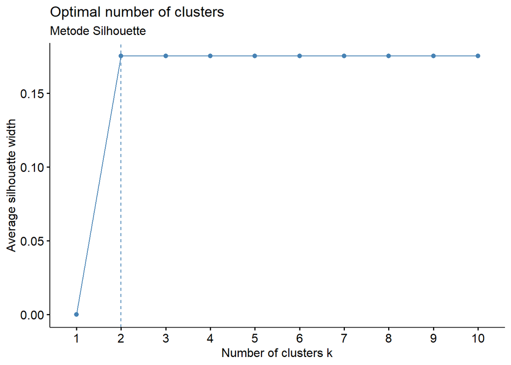

```r
library(cluster)
set.seed(123)

elbow <-
fviz_nbclust(
  x = covid_scale, #data
  FUNcluster = fanny, #fungsi clustering
  method = "silhouette") + labs(subtitle = "Metode Silhouette") #judul
elbow
```

> Nilai k optimum dari data `covid_FCM` didapatkan pada saat 2.

### 3.2.5 FCM menggunakan `fcm()`

Membuat object `fcm.covid` dengan menggunakan fungsi `fcm()` dengan jumlah k sesuai banyaknya nilai k optimum yang didapat.

Parameter:

- `x`: dataset
- `centers`: banyaknya centroid (nilai k)

```r
library(ppclust)
set.seed(123)
fcm.covid <- fcm(x = covid_FCM,
                  centers = 2)
summary(fcm.covid)
```

```
## Summary for 'fcm.covid'
##
## Number of data objects:  44
##
## Number of clusters:  2
##
## Crisp clustering vector:
##  [1] 1 2 1 2 1 1 1 1 2 2 1 1 2 1 2 1 1 2 1 1 2 2 1 1 1 2 2 2 2 1 1 1 1 1 2 1 2 2
## [39] 2 2 2 2 1 2
##
## Initial cluster prototypes:
##              lansia disabilitas kepadatan_penduduk penduduk_nonmuslim
## Cluster 1 0.0000000  0.05561904          0.1086198          0.3865473
## Cluster 2 0.3064559  0.03037189          0.1564692          0.1523000
##           pendidikan_rendah RS_covid rasio_ketergantungan        WNA        RS
## Cluster 1         0.6458134      0.8            0.3405406 0.05601652 0.1428571
## Cluster 2         0.1984026      0.2            0.4216217 0.10437702 0.1428571
##           tenaga_kesehatan    apotek puskesmas      balita positif_cov
## Cluster 1        0.4322880 0.5867769 0.9090909 0.007745482   0.5534890
## Cluster 2        0.4158945 0.2975207 0.2727273 0.035113105   0.5078441
##           rawat_cov isoman_cov
## Cluster 1 0.5140845  0.2857143
## Cluster 2 0.2957746  0.2342857
##
## Final cluster prototypes:
##              lansia disabilitas kepadatan_penduduk penduduk_nonmuslim
## Cluster 1 0.3936909   0.1188795          0.2254411          0.3127655
## Cluster 2 0.4591629   0.1166271          0.2285354          0.3414606
##           pendidikan_rendah  RS_covid rasio_ketergantungan       WNA        RS
## Cluster 1         0.3224934 0.4433548            0.3979552 0.2177715 0.2695025
## Cluster 2         0.3231679 0.4199911            0.3947412 0.2578983 0.2493198
##           tenaga_kesehatan    apotek puskesmas    balita positif_cov rawat_cov
## Cluster 1        0.4732257 0.4426290 0.4594368 0.1009901   0.5536850 0.4875869
## Cluster 2        0.4781012 0.4209334 0.4023419 0.1220504   0.4878545 0.4355515
##           isoman_cov
## Cluster 1  0.4168333
## Cluster 2  0.3583740
##
## Distance between the final cluster prototypes
##            Cluster 1
```

[output cut: 38 more lines]

```
##
## Dunn's Fuzziness Coefficients:
## dunn_coeff normalized
## 0.50516573 0.01033147
##
## Within cluster sum of squares by cluster:
##         1         2
##  9.986606 16.394065
## (between_SS / total_SS =  0.92%)
##
## Available components:
##  [1] "u"          "v"          "v0"         "d"          "x"
##  [6] "cluster"    "csize"      "sumsqrs"    "k"          "m"
## [11] "iter"       "best.start" "func.val"   "comp.time"  "inpargs"
## [16] "algorithm"  "call"
```

Hasil dari `fcm()` :

1. Untuk mengetahui jumlah kecamatan untuk setiap cluster

```r
fcm.covid$csize
```

```
##  1  2
## 23 21
```

**Insight**

- Untuk cluster 1 ada sejumlah 23 kecamatan
- Untuk cluster 2 ada sejumlah 21 kecamatan
2. Nilai untuk masing-masing kecamatan dan juga hasil cluster setiap kecamatannya.

```r
fcm.covid$cluster
```

```
##  1  2  3  4  5  6  7  8  9 10 11 12 13 14 15 16 17 18 19 20 21 22 23 24 25 26
##  1  2  1  2  1  1  1  1  2  2  1  1  2  1  2  1  1  2  1  1  2  2  1  1  1  2
## 27 28 29 30 31 32 33 34 35 36 37 38 39 40 41 42 43 44
##  2  2  2  1  1  1  1  1  2  1  2  2  2  2  2  2  1  2
```

```r
# membuat data frame gabungan antara rentan_FCM dengan hasil cluster
fcm_keep<-data.frame(covid_FCM, fcm.covid$cluster)
fcm_keep
```

|  | lansia | disabilitas | kepadatan_penduduk | penduduk_nonmuslim | pendidikan_rendah | RS_covid | rasio_ketergantungan | WNA | RS | tenaga_kesehatan | apotek | puskesmas | balita | positif_cov | rawat_cov | isoman_cov | fcm.covid.cluster |
| --- | --- | --- | --- | --- | --- | --- | --- | --- | --- | --- | --- | --- | --- | --- | --- | --- | --- |
| CAKUNG | 0.04693080 | 0.0533348338 | 0.144380221 | 0.1720661421 | 0.39375972 | 0.2 | 0.0000000 | 0.02791648 | 0.1428571 | 0.500000000 | 0.5123967 | 0.54545455 | 0.009841763 | 0.816213530 | 0.57746479 | 0.58285714 | 1 |
| CEMPAKA PUTIH | 0.67779574 | 0.0003984166 | 0.102711344 | 0.2684891634 | 0.07651272 | 1.0 | 0.3783785 | 0.26055028 | 0.2857143 | 0.686742694 | 0.3884298 | 0.09090909 | 0.075914343 | 0.337616242 | 0.35211268 | 0.09714286 | 2 |
| CENGKARENG | 0.09707556 | 0.3714720340 | 0.193044404 | 0.3853236627 | 0.56771177 | 0.2 | 0.3378379 | 0.08747682 | 0.1428571 | 0.690662865 | 1.0000000 | 0.63636364 | 0.000000000 | 0.908213246 | 0.76760563 | 0.83428571 | 1 |
| CILANDAK | 0.46795975 | 0.0289046624 | 0.090750690 | 0.1921608605 | 0.17701898 | 0.4 | 0.2756758 | 0.62736589 | 0.4285714 | 0.468282252 | 0.3223140 | 0.27272727 | 0.043761764 | 0.564988997 | 0.43661972 | 0.65142857 | 2 |
| CILINCING | 0.01395345 | 0.0115561738 | 0.209544218 | 0.1640548656 | 0.63079053 | 0.6 | 0.6486488 | 0.01321321 | 0.1428571 | 0.461867427 | 0.5289256 | 0.63636364 | 0.036191213 | 0.543550792 | 0.51408451 | 0.36000000 | 1 |
| CIPAYUNG | 0.15352836 | 1.0000000000 | 0.124580444 | 0.2065279831 | 0.24071021 | 0.2 | 0.3851352 | 0.02162390 | 0.0000000 | 0.462936565 | 0.4628099 | 0.72727273 | 0.074178783 | 0.723716902 | 0.44366197 | 0.70857143 | 1 |
| CIRACAS | 0.25610534 | 0.0801468722 | 0.147568930 | 0.2163202219 | 0.21319123 | 0.6 | 0.3729731 | 0.01530894 | 0.1428571 | 0.462936565 | 0.4958678 | 0.27272727 | 0.023405997 | 0.659260311 | 0.51408451 | 0.61714286 | 1 |
| DUREN SAWIT | 0.46288044 | 0.0702312065 | 0.253070181 | 0.2495157515 | 0.20389751 | 0.4 | 0.5328187 | 0.05099042 | 0.2857143 | 0.514967926 | 0.4958678 | 0.81818182 | 0.022745675 | 1.000000000 | 0.97887324 | 0.82857143 | 1 |
| GAMBIR | 1.00000000 | 0.0469334340 | 0.158702882 | 0.5575971298 | 0.19178045 | 0.4 | 0.2837839 | 0.26550032 | 0.1428571 | 0.523164647 | 0.2975207 | 0.09090909 | 0.201570822 | 0.252289345 | 0.17605634 | 0.24000000 | 2 |
| GROGOL PETAMBURAN | 0.74680051 | 0.7449021150 | 0.235755645 | 0.8385388332 | 0.24793560 | 0.4 | 0.3938225 | 0.34915490 | 0.4285714 | 0.641126158 | 0.9090909 | 0.63636364 | 0.079134901 | 0.571874778 | 0.47183099 | 0.24571429 | 2 |

[output cut: 34 more lines]

```r
# Inspeksi nilai-nilai kecamatan permasing-masing cluster
cluster_1 <- fcm_keep %>%
  filter(fcm.covid.cluster %in% 1)
cluster_1
```

|  | lansia | disabilitas | kepadatan_penduduk | penduduk_nonmuslim | pendidikan_rendah | RS_covid | rasio_ketergantungan | WNA | RS | tenaga_kesehatan | apotek | puskesmas | balita | positif_cov | rawat_cov | isoman_cov | fcm.covid.cluster |
| --- | --- | --- | --- | --- | --- | --- | --- | --- | --- | --- | --- | --- | --- | --- | --- | --- | --- |
| CAKUNG | 0.04693080 | 0.05333483 | 0.14438022 | 0.1720661 | 0.3937597 | 0.2 | 0.0000000 | 0.02791648 | 0.1428571 | 0.5000000 | 0.5123967 | 0.5454545 | 0.009841763 | 0.8162135 | 0.5774648 | 0.5828571 | 1 |
| CENGKARENG | 0.09707556 | 0.37147203 | 0.19304440 | 0.3853237 | 0.5677118 | 0.2 | 0.3378379 | 0.08747682 | 0.1428571 | 0.6906629 | 1.0000000 | 0.6363636 | 0.000000000 | 0.9082132 | 0.7676056 | 0.8342857 | 1 |
| CILINCING | 0.01395345 | 0.01155617 | 0.20954422 | 0.1640549 | 0.6307905 | 0.6 | 0.6486488 | 0.01321321 | 0.1428571 | 0.4618674 | 0.5289256 | 0.6363636 | 0.036191213 | 0.5435508 | 0.5140845 | 0.3600000 | 1 |
| CIPAYUNG | 0.15352836 | 1.00000000 | 0.12458044 | 0.2065280 | 0.2407102 | 0.2 | 0.3851352 | 0.02162390 | 0.0000000 | 0.4629366 | 0.4628099 | 0.7272727 | 0.074178783 | 0.7237169 | 0.4436620 | 0.7085714 | 1 |
| CIRACAS | 0.25610534 | 0.08014687 | 0.14756893 | 0.2163202 | 0.2131912 | 0.6 | 0.3729731 | 0.01530894 | 0.1428571 | 0.4629366 | 0.4958678 | 0.2727273 | 0.023405997 | 0.6592603 | 0.5140845 | 0.6171429 | 1 |
| DUREN SAWIT | 0.46288044 | 0.07023121 | 0.25307018 | 0.2495158 | 0.2038975 | 0.4 | 0.5328187 | 0.05099042 | 0.2857143 | 0.5149679 | 0.4958678 | 0.8181818 | 0.022745675 | 1.0000000 | 0.9788732 | 0.8285714 | 1 |
| JAGAKARSA | 0.19128910 | 0.08350129 | 0.14053597 | 0.1089275 | 0.2334162 | 0.6 | 0.4189190 | 0.11345539 | 0.4285714 | 0.3841768 | 0.2561983 | 0.2727273 | 0.028414764 | 0.8194080 | 0.5633803 | 1.0000000 | 1 |
| JATINEGARA | 0.46869349 | 0.03582970 | 0.46361397 | 0.2636074 | 0.3117701 | 0.6 | 0.4155407 | 0.07824720 | 0.2857143 | 0.5819672 | 0.5702479 | 0.8181818 | 0.058632709 | 0.6180166 | 0.3873239 | 0.4971429 | 1 |
| KALI DERES | 0.00000000 | 0.05561904 | 0.10861978 | 0.3865473 | 0.6458134 | 0.8 | 0.3405406 | 0.05601652 | 0.1428571 | 0.4322880 | 0.5867769 | 0.9090909 | 0.007745482 | 0.5534890 | 0.5140845 | 0.2857143 | 1 |
| KEBAYORAN LAMA | 0.40121807 | 0.04508764 | 0.18417319 | 0.2171418 | 0.2403649 | 0.6 | 0.3513512 | 0.43515709 | 0.2857143 | 0.5103350 | 0.3388430 | 0.5454545 | 0.025088598 | 0.6483282 | 0.5352113 | 0.4742857 | 1 |

[output cut: 13 more lines]

```r
cluster_2 <- fcm_keep %>%
  filter(fcm.covid.cluster %in% 2)
cluster_2
```

|  | lansia | disabilitas | kepadatan_penduduk | penduduk_nonmuslim | pendidikan_rendah | RS_covid | rasio_ketergantungan | WNA | RS | tenaga_kesehatan | apotek | puskesmas | balita | positif_cov | rawat_cov | isoman_cov | fcm.covid.cluster |
| --- | --- | --- | --- | --- | --- | --- | --- | --- | --- | --- | --- | --- | --- | --- | --- | --- | --- |
| CEMPAKA PUTIH | 0.67779574 | 0.0003984166 | 0.102711344 | 0.2684891634 | 0.07651272 | 1.0 | 0.3783785 | 0.26055028 | 0.2857143 | 0.686742694 | 0.3884298 | 0.09090909 | 0.07591434 | 0.337616242 | 0.35211268 | 0.09714286 | 2 |
| CILANDAK | 0.46795975 | 0.0289046624 | 0.090750690 | 0.1921608605 | 0.17701898 | 0.4 | 0.2756758 | 0.62736589 | 0.4285714 | 0.468282252 | 0.3223140 | 0.27272727 | 0.04376176 | 0.564988997 | 0.43661972 | 0.65142857 | 2 |
| GAMBIR | 1.00000000 | 0.0469334340 | 0.158702882 | 0.5575971298 | 0.19178045 | 0.4 | 0.2837839 | 0.26550032 | 0.1428571 | 0.523164647 | 0.2975207 | 0.09090909 | 0.20157082 | 0.252289345 | 0.17605634 | 0.24000000 | 2 |
| GROGOL PETAMBURAN | 0.74680051 | 0.7449021150 | 0.235755645 | 0.8385388332 | 0.24793560 | 0.4 | 0.3938225 | 0.34915490 | 0.4285714 | 0.641126158 | 0.9090909 | 0.63636364 | 0.07913490 | 0.571874778 | 0.47183099 | 0.24571429 | 2 |
| JOHAR BARU | 0.48355587 | 0.0456477322 | 0.488350001 | 0.2586313379 | 0.47621723 | 0.2 | 0.4459461 | 0.03648000 | 0.0000000 | 0.727726301 | 0.4049587 | 0.36363636 | 0.07354437 | 0.279477532 | 0.17605634 | 0.10857143 | 2 |
| KEBAYORAN BARU | 0.62233733 | 0.0288007994 | 0.178685800 | 0.2098078425 | 0.13596285 | 0.6 | 0.2270271 | 1.00000000 | 0.4285714 | 0.562722737 | 0.3553719 | 0.72727273 | 0.21930422 | 0.434585078 | 0.38732394 | 0.56000000 | 2 |
| KELAPA GADING | 0.97145883 | 0.0054855628 | 0.025162217 | 1.0000000000 | 0.00000000 | 0.4 | 0.4864866 | 0.81678385 | 0.2857143 | 0.269422666 | 0.3223140 | 0.18181818 | 0.04249599 | 0.402995670 | 0.42957746 | 0.34285714 | 2 |
| KEP. SERIBU SLT | 0.07562168 | 0.6590162061 | 0.000000000 | 0.0000000000 | 1.00000000 | 0.0 | 1.0000000 | 0.00000000 | 0.0000000 | 0.000000000 | 0.0000000 | 0.09090909 | 1.00000000 | 0.000000000 | 0.00000000 | 0.00000000 | 2 |
| KEP. SERIBU UTR | 0.06598185 | 0.1016075163 | 0.005740703 | 0.0008309164 | 0.92883448 | 0.0 | 0.6216221 | 0.00000000 | 0.1428571 | 0.004632929 | 0.0000000 | 0.18181818 | 0.72328164 | 0.005324058 | 0.02112676 | 0.02285714 | 2 |
| MAMPANG PRAPATAN | 0.28165521 | 0.1074303646 | 0.193064943 | 0.1131982241 | 0.26515178 | 0.6 | 0.2594595 | 0.71201311 | 0.0000000 | 0.447255880 | 0.3223140 | 0.36363636 | 0.08936252 | 0.392489529 | 0.16901408 | 0.25142857 | 2 |

[output cut: 11 more lines]

- **Kluster 1** berisi **23 Kecamatan**
- **Kluster 2** berisi **21 Kecamatan**

### 3.2.6 Interpretasi: Cluster Profiling

Untuk dapat melakukan cluster profiling, dibutuhkan informasi pusat cluster (centroid) masing-masing variabel terhadap cluster yang dihasilkan. Dalam object `fcm.covid`, kita dapat melakukan inspeksi menggunakan `fcm.covid$v` yang mana merupakan matriks numerik yang berisi pusat masing-masing cluster (centroid).

Final cluster prototype

```r
fcm.covid$v
```

```
##              lansia disabilitas kepadatan_penduduk penduduk_nonmuslim
## Cluster 1 0.3936909   0.1188795          0.2254411          0.3127655
## Cluster 2 0.4591629   0.1166271          0.2285354          0.3414606
##           pendidikan_rendah  RS_covid rasio_ketergantungan       WNA        RS
## Cluster 1         0.3224934 0.4433548            0.3979552 0.2177715 0.2695025
## Cluster 2         0.3231679 0.4199911            0.3947412 0.2578983 0.2493198
##           tenaga_kesehatan    apotek puskesmas    balita positif_cov rawat_cov
## Cluster 1        0.4732257 0.4426290 0.4594368 0.1009901   0.5536850 0.4875869
## Cluster 2        0.4781012 0.4209334 0.4023419 0.1220504   0.4878545 0.4355515
##           isoman_cov
## Cluster 1  0.4168333
## Cluster 2  0.3583740
```

Cluster Profiling:

- **Cluster 1** :
  - Pada cluster ini dominan variabel yang terkait sarana RS, RS Covid, apotek, rasio_ketergantungan, positif_cov, rawat_cov dan isoman_cov
  - Untuk variabel positiv_cov, rawat, dan juga isoman, variabel- variabel ini menjadi masalah di kecamatan-kecamatan yang ada pada cluster 1. hal ini dibuktikan dengan nilai jumlah positif covid, jumlah orang yang dirawat, serta jumlah orang melakukan isoman akibat COVID yang tinggi.
- **Cluster 2** :
  - Pada cluster ini dominan variabel yang terkait var terkait umur penderita, kepadatan penduduk, status agama, status warga negara dan tenaga_kesehatan
  - Lansia pada kecamatan-kecamatan yang ada di cluster 2 memang memiliki persentase nilai yang tinggi pada data asli. Hal ini mengindikasikan, kecamatan-kecamatan yang ada di cluster 2 bisa dilakukan penanggulangan atau bantuan yang dikhususkan untuk lansia.
  - keadaan positive_cov menyebabkan banyaknya warga yang harus diisoman dan di beberapa kecamatan terlihat lebih sedikit yang perlu dirawat

```r
covid %>%
  select(c(Kecamatan, positif_cov, rawat_cov, isoman_cov))
```

| Kecamatan | positif_cov | rawat_cov | isoman_cov |
| --- | --- | --- | --- |
| CAKUNG | 11740 | 82 | 102 |
| CEMPAKA PUTIH | 4998 | 50 | 17 |
| CENGKARENG | 13036 | 109 | 146 |
| CILANDAK | 8201 | 62 | 114 |
| CILINCING | 7899 | 73 | 63 |
| CIPAYUNG | 10437 | 63 | 124 |
| CIRACAS | 9529 | 73 | 108 |
| DUREN SAWIT | 14329 | 139 | 145 |
| GAMBIR | 3796 | 25 | 42 |
| GROGOL PETAMBURAN | 8298 | 67 | 43 |

[output cut: 34 more lines]

Berikut merupakan hasil visualisasi kluster dalam plot 2 dimensi.

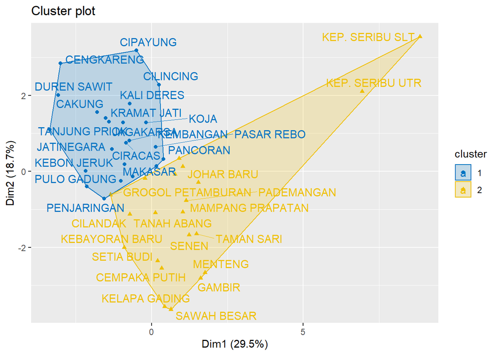

```r
# mengubah object ppclust menjadi tipe lain dari object cluster
fcm.covid2 <- ppclust2(fcm.covid, "fanny")
# gunakan fungsi fviz_cluster() dari package factoextra
factoextra::fviz_cluster(fcm.covid2, data = covid_FCM,
  ellipse.type = "convex",
  palette = "jco",
  repel = TRUE)
```

> Untuk daerah yang terletak di antara 2 cluster atau memiliki membership degree yang fifty-fifty indikasinya daerah/kecamatan tersebut cenderung memiliki nilai yang cukup dominan/tinggi di variabel-varibel keseluruhan.

## 3.3 Implikasi Kebijakan

Peta kerentanan sosial juga dapat menjadi informasi yang baik dalam penanggulangan bencana. Integrasi dengan sistem peringatan yang dirancang untuk mencegah penularan penyakit dapat memberikan informasi yang berguna bagi wilayah yang memiliki risiko penyebaran COVID-19 yang tinggi. Permasalahan yang disebabkan oleh kependudukan, pekerjaan, kesehatan, dan pendidikan yang diakibatkan oleh COVID-19, dapat ditanggulangi dengan mengintegrasikan perencanaan penanggulangan resiko dengan program pengembangan lainnya.

Pada analisis ini ditemukan 2 faktor yang berpengaruh terhadap kerentanan sosial yaitu Faktor Kesehatan dan Fasilitas Penunjang serta Faktor Usia Penderita, oleh karena itu, disarankan bahwa penanggulan dampak COVID-19 dapat diintegrasikan dengan program pengembangan lainnya yang sesuai dengan beberapa faktor yang telah disebutkan.

Oleh karena itu, hasil analisis ini dapat menjadi masukan bagi pemerintah dalam hal ini Badan Penanggulangan Bencana Daerah (BPBD) DKI Jakarta, dimana hasilnya dapat digunakan untuk perencanaan program penanggulangan bencana kedepannya. Lebih jauh lagi berdasarkan hasil analisis ini dapat dilihat tingkat kerentanan yang berbeda pada masing-masing wilayah, Hal ini berarti kapasitas kesiapan dan respon terhadap COVID-19 berbeda beda. Bagi CSR perusahaan, hal ini dapat menjadi rujukan informasi yang bersesuaian agar lebih tepat sasaran dalam memberikan bantuan kepada daerah dengan karakteristik tertentu

Ketika informasi yang terbatas, penggunaan peta kerentanan sosial dapat dijadikan informasi untuk memprioritaskan terlebih dahulu daerah dengan tingkat kerentanan sosial yang tinggi.

## 3.4 Kesimpulan

Analisis ini merupakan upaya yang dilakukan untuk mendukung penanggulangan dampak yang diakibatkan oleh COVID-19 di DKI Jakarta. Pendekatan indeks dan klaster dilakukan untuk mengetahui bagaimana indeks kerentanan dan pengaruh variabel terhadap masing-masing wilayah kecamatan DKI Jakarta. Dari project ini, kami mendapatkan 2 faktor yang membentuk kerentanan sosial, yaitu Kesehatan dan Fasilitas Penunjang serta Faktor Usia Penderita.

Terima kasih.